# P2_Dacko

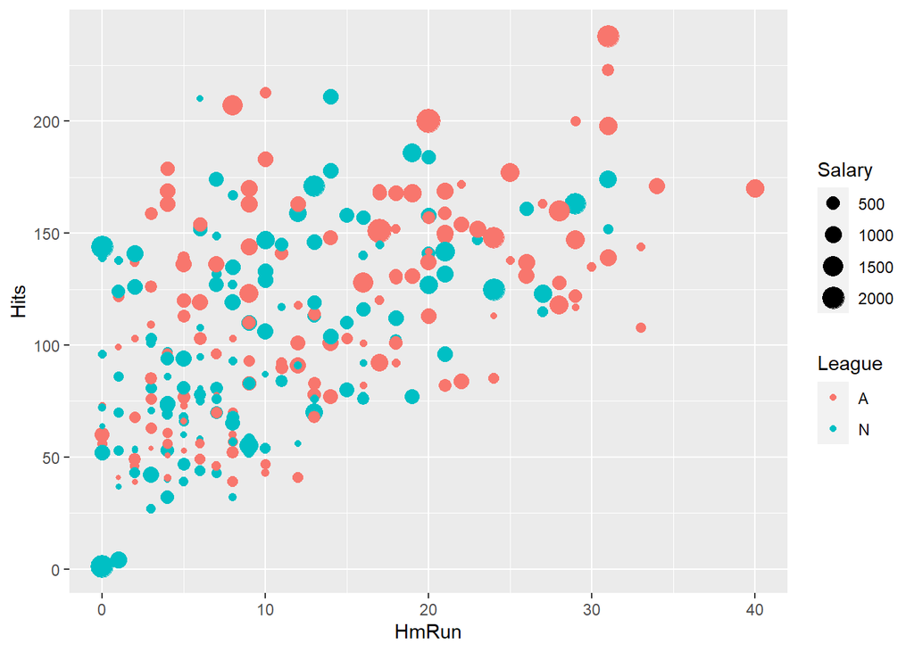

```r
 ggplot(Hitters, aes(y = Hits, x = HmRun, colour=League,size=Salary)) +
  geom_point()
```

There are two types of geoms:

- geoms which perform a transformation of the data beforehand, such as geom_density_2d() which calculates contour lines from x and y positions.
- geoms which do not transform data beforehand, but use the aesthetic mapping directly, such as geom_point().

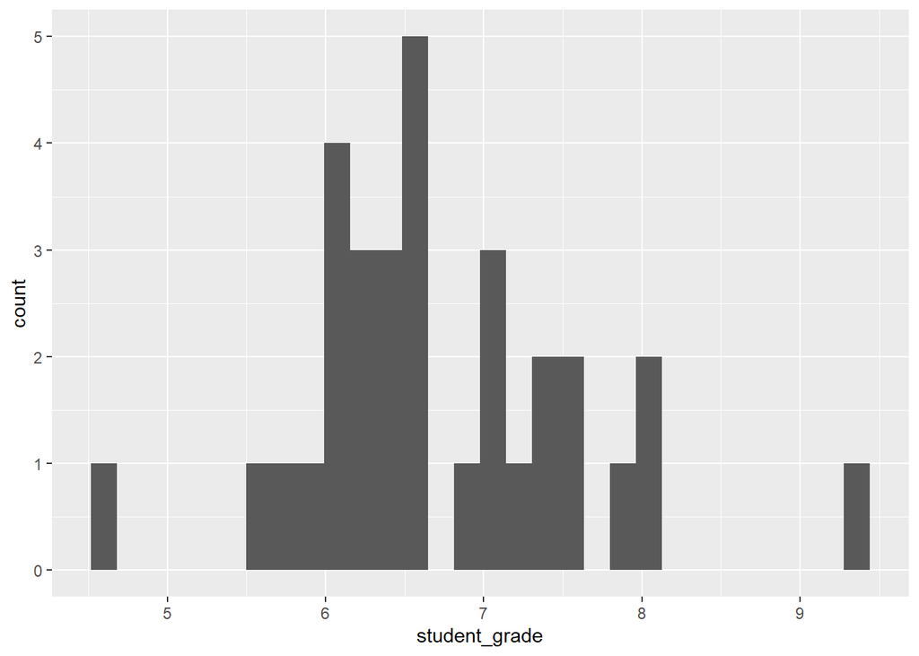

```r
gg_students %>% ggplot(aes(student_grade))+geom_histogram()
```

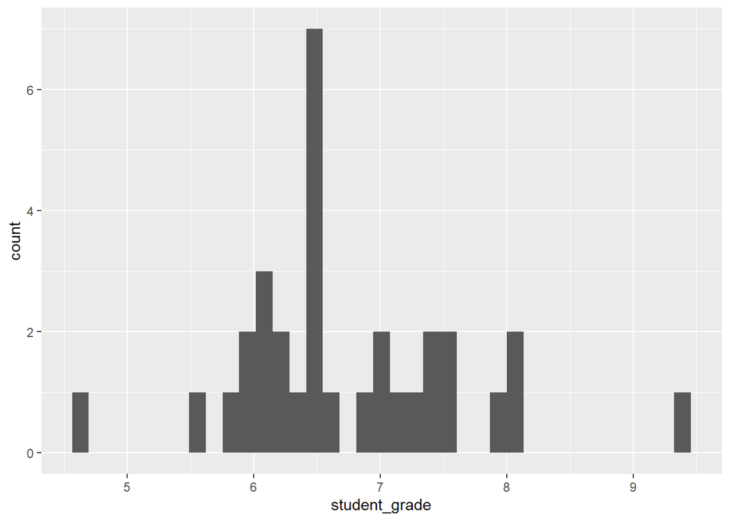

```r
gg_students %>% ggplot(aes(student_grade))+geom_histogram(bins=37)
```

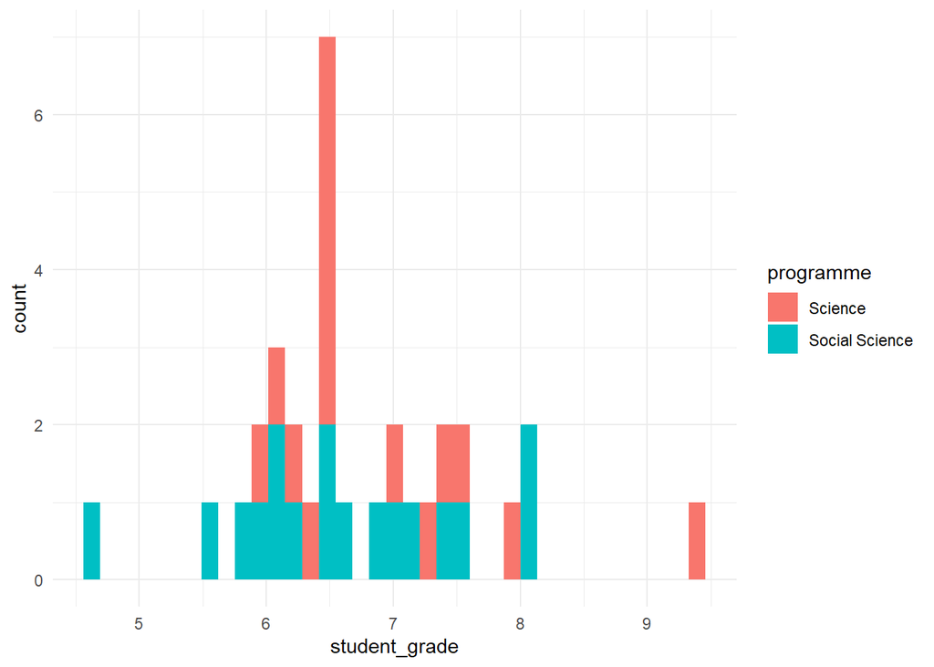

```r
gg_students %>% ggplot(aes(student_grade,fill=programme))+geom_histogram(bins=37)+  theme_minimal()
```

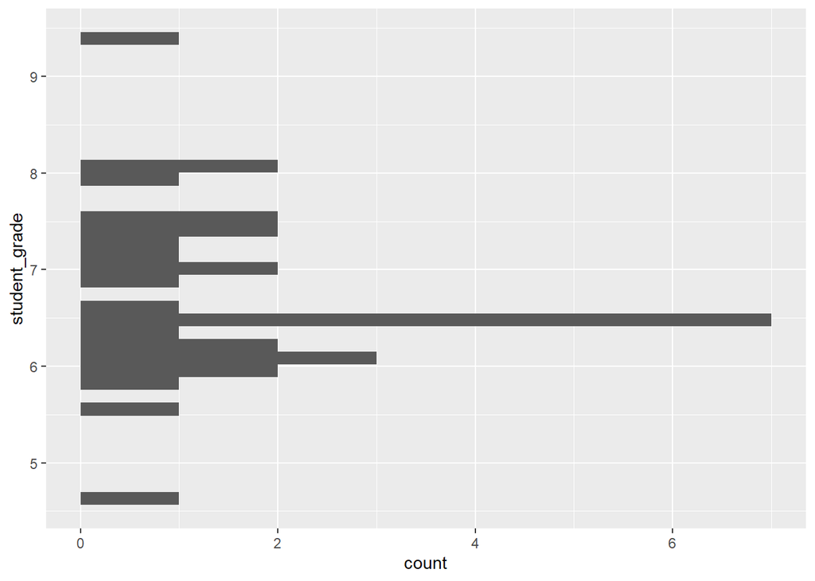

```r
gg_students %>% ggplot(aes(y=student_grade))+geom_histogram(bins=37)
```

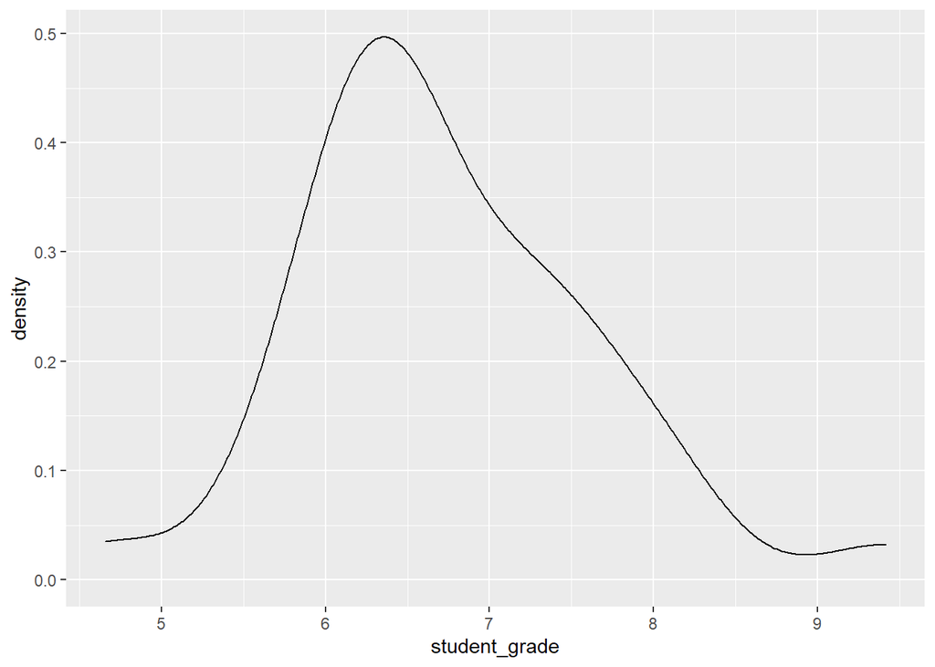

```r
gg_students %>% ggplot(aes(student_grade))+geom_density()
```

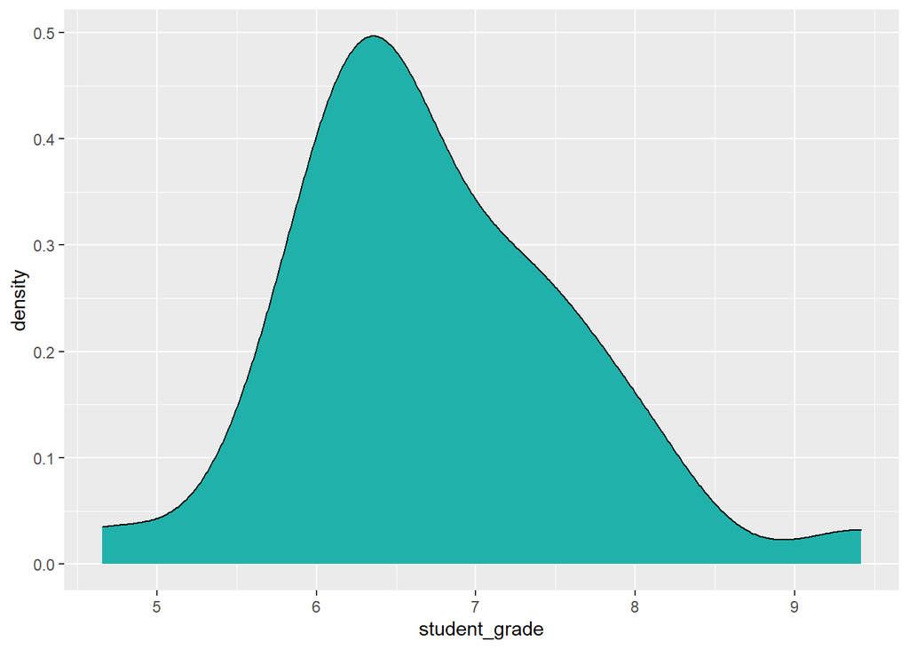

```r
gg_students %>% ggplot(aes(student_grade))+geom_density(fill = "light seagreen")
```

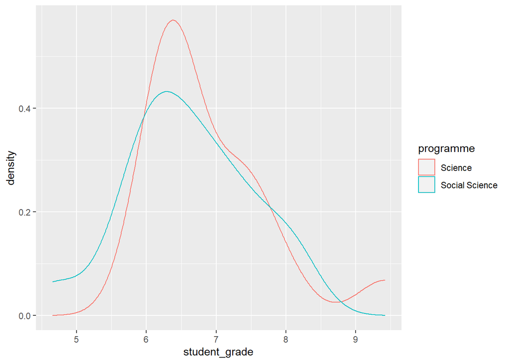

```r
gg_students %>% ggplot(aes(student_grade, colour=programme))+geom_density()
```

8.

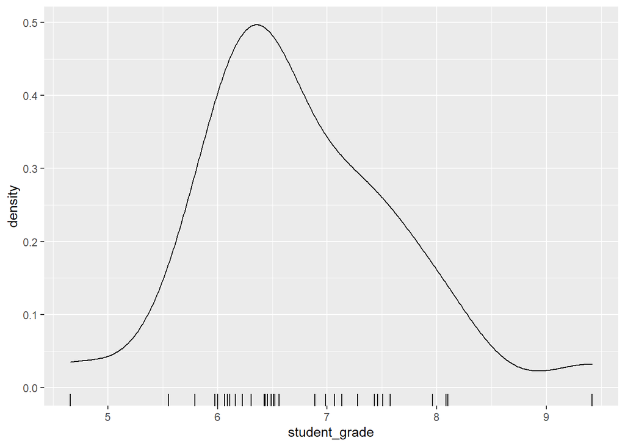

```r
gg_students %>% ggplot(aes(student_grade))+geom_density()+geom_rug()
```

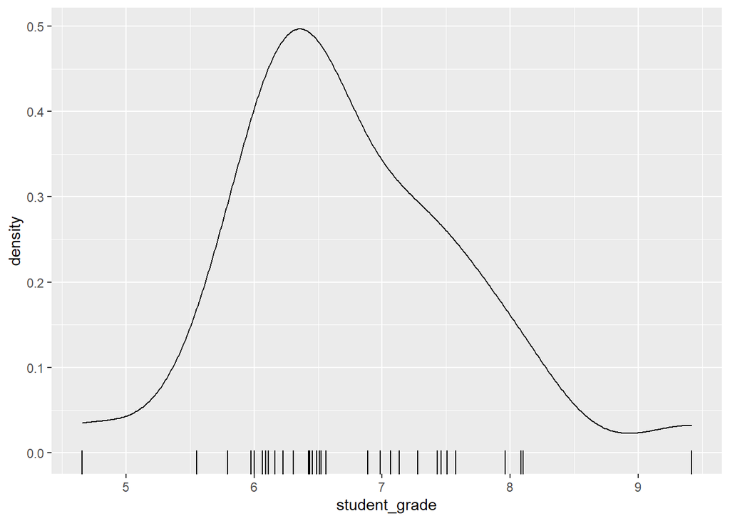

```r
gg_students %>% ggplot(aes(student_grade))+geom_density()+geom_rug(length = unit(0.05, "npc"))
```

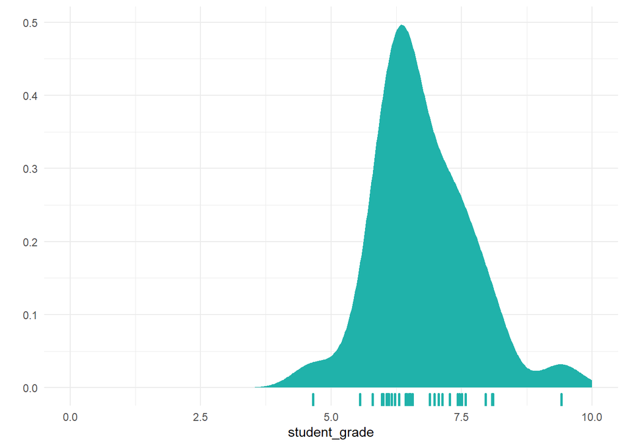

```r
gg_students %>%
  ggplot(aes(x = student_grade)) +
  geom_density(fill = "light seagreen", colour = NA) +
  geom_rug(size = 1, colour = "light seagreen") +
  theme_minimal() +
  labs(y = "") +
  xlim(0, 10)
```

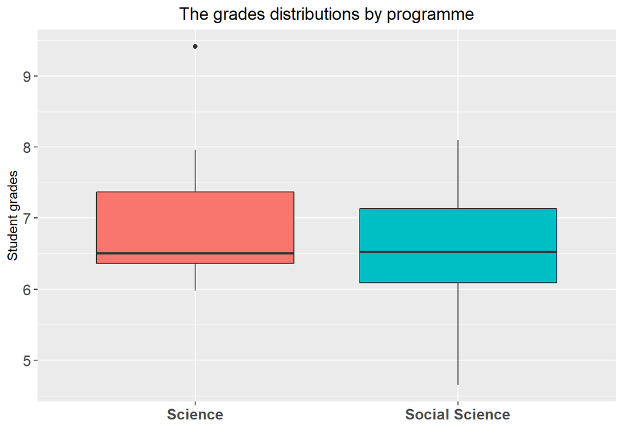

```r
gg_students %>%
  ggplot(aes(x = programme, y = student_grade, fill = programme)) +
  geom_boxplot() +ggtitle("The grades distributions by programme")+theme(plot.title=element_text(size=14,hjust = 0.5),legend.position="none",axis.text.x=element_text(size=12,face="bold"),axis.text.y=element_text(size=12))+xlab("")+ylab("Student grades")
```

The middle line indicates the median, the outer horizontal lines are the 25th and 75th percentile. The upper whisker extends from the hinge to the largest value no further than 1.5 * IQR from the hinge (where IQR is the inter-quartile range, or distance between the first and third quartiles). The lower whisker extends from the hinge to the smallest value at most 1.5 * IQR of the hinge. Data beyond the end of the whiskers are called “outlying” points and are plotted individually. 12.

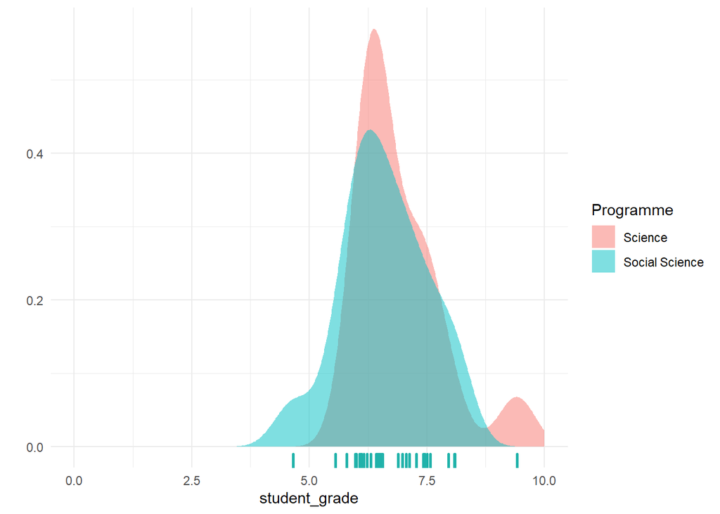

```r
gg_students %>%
  ggplot(aes(x = student_grade, fill = programme)) +
  geom_density(alpha = .5, colour = NA) +
  geom_rug(size = 1, colour = "light seagreen") +
  theme_minimal() +
  labs(y = "", fill = "Programme") +
  xlim(0, 10)
```

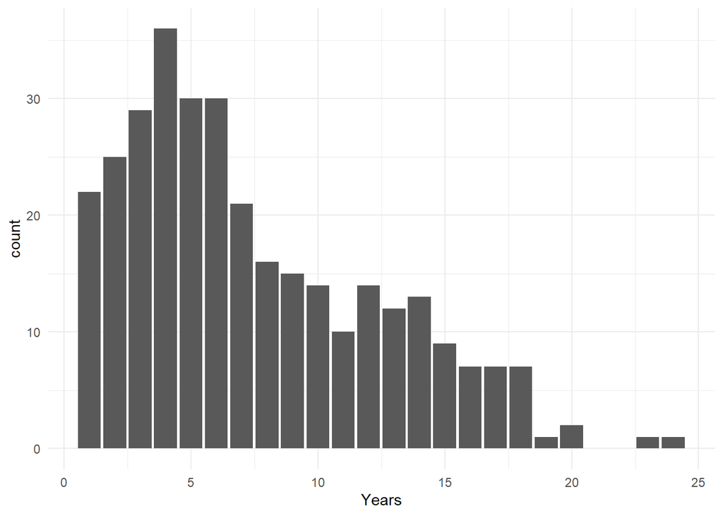

```r
Hitters %>%
  ggplot(aes(x = Years)) +
  geom_bar() +
  theme_minimal()
```